# Czynniki wpływające na czas rozwiązywania zadań z matematyki PISA 2015 - etap I

Zofia Nawalany, Michał Karlicki, Agata Gruszczyńska

22 marca 2017

# Cel

Celem pierwszego etapu projektu jest zbudowanie modelu liniowego na podstawie danych z PISA 2015, a dokładniej, modelu opartego o cechy zadania - jego ID oraz pozycję w kwestionariuszu.

# Dane i ich preparatyka

Źródło danych do jego utworzenia stanowiła tabela PISA 2015 **“actionTimeScoreMath”, którą skrótowo nazwano w poniżej pracy “atsm”**. Wykorzystano z niej następujące informacje: -czas (“T”) -pozycję w kwestionariuszu (“position”) -ID zadania (“item_short”)

Dodatkowo stworzono analogiczną tabelę **atsm2** w której policzono całkowity czas jaki uczeń potrzebował na jego rozwiązanie (zsumowany czas wszystkich popunktów zadania).

```r
atsm<-actionTimeScoreMath
```

Przed przystąpieniem do analizy **ze zbioru usunięto wybrane wiersze**. Były to te, zawierające wartości **“-1” i “NA” w kolumnie “position”** oraz wartości **“NA” w kolumnie “T” bądź “CNT”**.

# Utworzone modele

-model_liniowy1 badający zależność zlogarytmowanego czasu odpodpunktu  
-model_liniowy2 badający zależność zlogarytmowanego czasu od pozycji zadania w kwestionariuszu  
-model_liniowy3 model z zagnieżdżeniem ID zadania w pozycji  
-model_liniowy4 model uwzględniający interakcje między ID zadania a pozycją w kwestionariuszu  
-model_liniowy5 model badający zależność między czasem całego zadania a pozycją w kwestionariuszu  
-model_liniowy6 model badajacy zależność między czasem całego zadania a ID zadania  
-model_liniowy7 model badający zależności między czasme całego zadania a jego pozycją z zagnieżdżonym ID zadania

Dla uproszczenia obliczeń modele zostały stworzone na podstawie losowo wybranej podgrupy danych.

```r
sample_df <- atsm[sample(nrow(atsm), 100000), ]
model_liniowy1 <- lm(log(T)~item_short,data=sample_df)
model_liniowy2 <- lm(log(T)~position,data=sample_df)
model_liniowy3 <- lm(log(T)~position/item_short, data=sample_df)
model_liniowy4 <- lm(log(T)~position*item_short, data=sample_df)
model_liniowy5 <- lm(log(question_time)~position,data=atsm2)
model_liniowy6 <- lm(log(question_time)~item,data=atsm2)
model_liniowy7 <- lm(log(question_time)~position/item,data=atsm2)
```

# Wybór Modelu

Do dalszej pracy zostały wybrane modele: model_liniowy3 oraz model_liniowy7. Modele te mają istotny wpływ zagnieżdczonych zmiennych objaśnianych (p-wartość poniżej 2e-16), również niosą ciekawe dla nas informacje. Różnią się natomiast danymi: w modelu siódmym zmienną objaśnianą jest czas pełnych zadań (nie podpunktów), a jedną ze zmiennych objaśniających jest nr. zadania nie podpunktów.

```r
anova(model_liniowy1)
```

```
## Analysis of Variance Table
##
## Response: log(T)
##               Df Sum Sq Mean Sq F value    Pr(>F)
## item_short    59   8703 147.513  238.12 < 2.2e-16 ***
## Residuals  99940  61912   0.619
## ---
## Signif. codes:  0 '***' 0.001 '**' 0.01 '*' 0.05 '.' 0.1 ' ' 1
```

```r
anova(model_liniowy2)
```

```
## Analysis of Variance Table
##
## Response: log(T)
##              Df Sum Sq Mean Sq F value    Pr(>F)
## position      3    853 284.487  407.78 < 2.2e-16 ***
## Residuals 99996  69761   0.698
## ---
## Signif. codes:  0 '***' 0.001 '**' 0.01 '*' 0.05 '.' 0.1 ' ' 1
```

```r
anova(model_liniowy3)
```

```
## Analysis of Variance Table
##
## Response: log(T)
##                        Df Sum Sq Mean Sq F value    Pr(>F)
## position                3    853 284.487  467.88 < 2.2e-16 ***
## position:item_short   236   9103  38.574   63.44 < 2.2e-16 ***
## Residuals           99760  60658   0.608
## ---
## Signif. codes:  0 '***' 0.001 '**' 0.01 '*' 0.05 '.' 0.1 ' ' 1
```

```r
anova(model_liniowy4)
```

```
## Analysis of Variance Table
##
## Response: log(T)
##                        Df Sum Sq Mean Sq F value    Pr(>F)
## position                3    853 284.487 467.877 < 2.2e-16 ***
## item_short             59   8682 147.160 242.024 < 2.2e-16 ***
## position:item_short   177    421   2.379   3.912 < 2.2e-16 ***
## Residuals           99760  60658   0.608
## ---
## Signif. codes:  0 '***' 0.001 '**' 0.01 '*' 0.05 '.' 0.1 ' ' 1
```

```r
anova(model_liniowy5)
```

```
## Analysis of Variance Table
##
## Response: log(question_time)
##             Df Sum Sq Mean Sq F value    Pr(>F)
## position     3   65.2  21.718   40.44 < 2.2e-16 ***
## Residuals 7144 3836.6   0.537
## ---
## Signif. codes:  0 '***' 0.001 '**' 0.01 '*' 0.05 '.' 0.1 ' ' 1
```

```r
anova(model_liniowy6)
```

```
## Analysis of Variance Table
##
## Response: log(question_time)
##             Df Sum Sq Mean Sq F value    Pr(>F)
## item        35 1538.1  43.945  132.23 < 2.2e-16 ***
## Residuals 7112 2363.6   0.332
## ---
## Signif. codes:  0 '***' 0.001 '**' 0.01 '*' 0.05 '.' 0.1 ' ' 1
```

```r
anova(model_liniowy7)
```

```
## Analysis of Variance Table
##
## Response: log(question_time)
##                 Df  Sum Sq Mean Sq F value    Pr(>F)
## position         3   65.15 21.7178  67.757 < 2.2e-16 ***
## position:item  140 1591.63 11.3688  35.470 < 2.2e-16 ***
## Residuals     7004 2244.94  0.3205
## ---
## Signif. codes:  0 '***' 0.001 '**' 0.01 '*' 0.05 '.' 0.1 ' ' 1
```

# Materiały dodatkowe

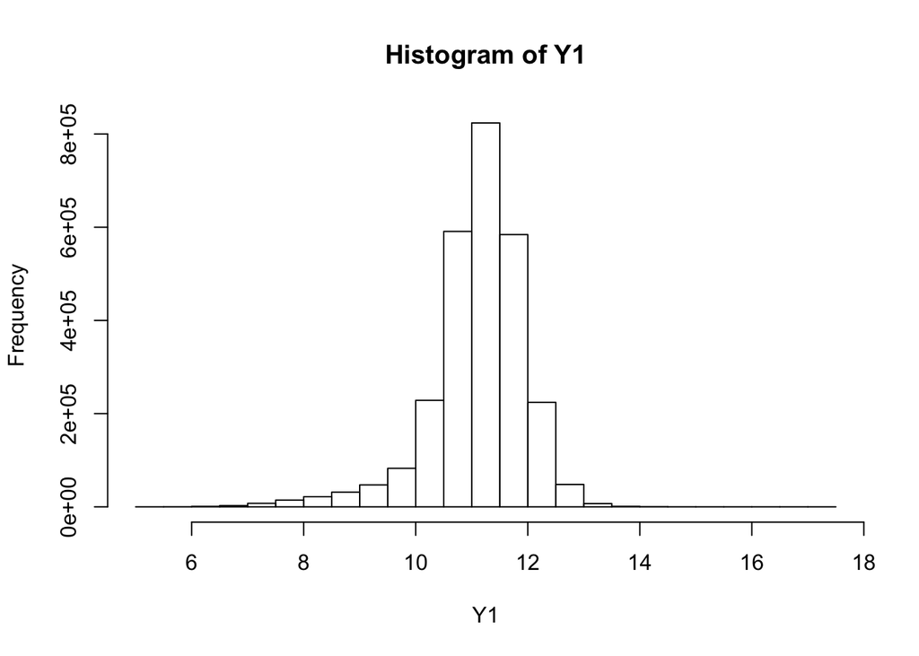

```r
Y1<-log(atsm$T)
hist(Y1)
```

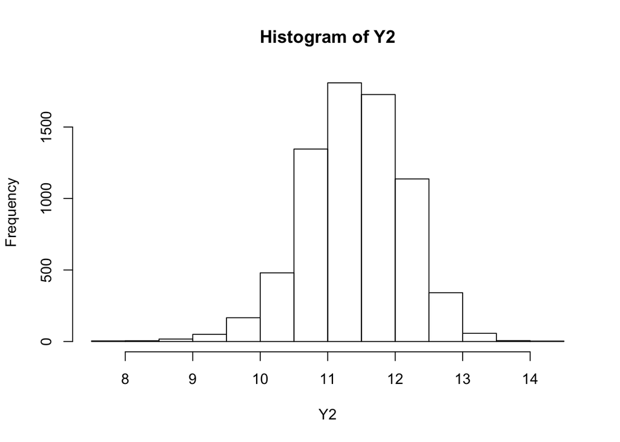

```r
Y2 <- log(atsm2$question_time)
hist(Y2)
```